# Kostumisasi Tampilan

Muhammad Aswan Syahputra

Anda telah berhasil membuat berbagai jenis grafik pada modul 003. Pada modul ini Anda akan diperkenalkan dengan beberapa cara untuk melakukan kostumisasi tampilan dan membuat *branding* akan grafik-grafik yang dibuat. Anda akan menggunakan dataset household_access untuk membuat *scatterplot* dalam modul ini.

```r
load("../data/household_access.rda")
household_access
```

```
##                      province year electricity_total
## 1                        Bali 1996          89.36000
## 2                    Bengkulu 1996          55.30000
## 3               DI Yogyakarta 1996          85.57000
## 4                 DKI Jakarta 1996          99.24000
## 5                       Jambi 1996          48.28000
## 6                  Jawa Barat 1996          82.75000
## 7                 Jawa Tengah 1996          80.32000
## 8                  Jawa Timur 1996          77.80000
## 9            Kalimantan Barat 1996          48.96000
## 10         Kalimantan Selatan 1996          64.49000
## 11          Kalimantan Tengah 1996          52.59000
## 12           Kalimantan Timur 1996          77.43000
## 13                    Lampung 1996          32.28000
## 14                     Maluku 1996          56.13000
```

[output cut: 275 more lines]

Selanjutnya Anda diminta untuk mengaktifkan paket ggplot2, magick, dan grid. Isilah bagian ___ dengan jawaban yang tepat!

```r
library(ggplot2)
library(magick)
library(grid)
```

Dengan menggunakan dataset household_access, buatlah *scatterplot* dengan nama plot_household berdasarkan kriteria berikut:

1. Sumbu x: electricity_total
2. Sumbu y: safe_sanitation
3. *Aesthetic mapping size*: safe_water
4. *Aesthetic mapping colour*: year

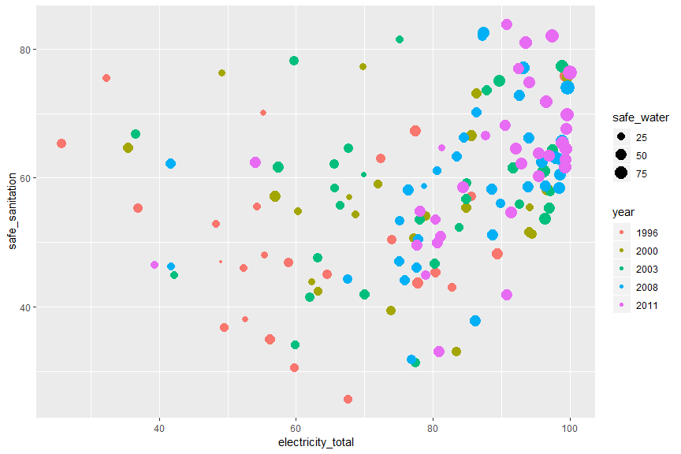

```r
plot_household <-
  household_access %>%
  ggplot(aes(x = electricity_total, y = safe_sanitation, size = safe_water, colour = year)) +
  geom_point()
plot_household
```

Pada grafik tersebut nampak banyak titik-titik observasi yang menumpuk. Perbakilah hal tersebut dengan mengatur nilai argumen `alpha` dalam baris kode `geom_point()`. Anda dapat bereksperimen mencari visual yang sesuai dengan menggunakan nilai alpha antara 0 hingga 1. Selain itu gantilah palet warna dari *aesthetic mapping colour* dengan menambahkan kode warna (*hexvalue*): “#162c4f”, “#2c89a0”, “#37c871”, “#b3b3b3”, dan “#2c62a0” ke baris kode `scale_color_manual()`. Simpan grafik hasil modifikasi Anda tersebut dalam obyek R dengan nama plot_household seperti sebelumnya!

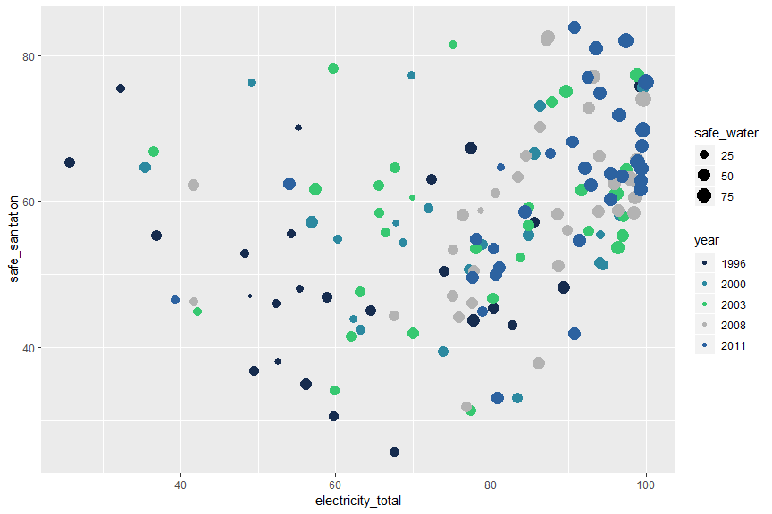

```r
plot_household <-
  plot_household +
  geom_point(alpha = 1) +
  scale_colour_manual(values = c("#162c4f",
                                 "#2c89a0",
                                 "#37c871",
                                 "#b3b3b3",
                                 "#2c62a0"))
plot_household
```

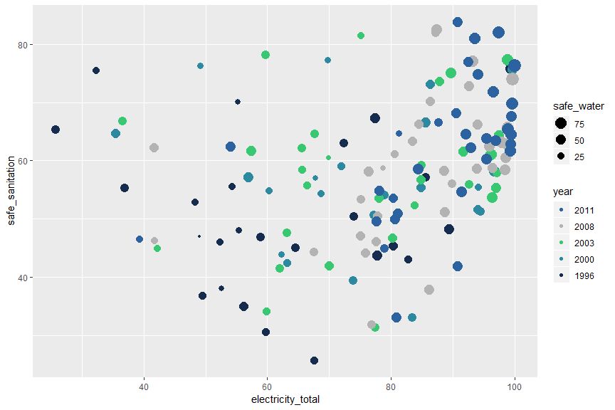

```r
plot_household <-
  plot_household +
  guides(size = guide_legend(reverse = TRUE, order = 1),
         colour = guide_legend(reverse = TRUE, order = 2 ))
plot_household
```

Selanjutnya Anda diminta untuk mengganti judul, subjudul, label sumbu x dan y, judul legenda, serta menambahkan *caption* untuk mensitir penyedia data yaitu The World Bank tahun 2019. Anda dapat melakukannya dengan menambahkan baris kode `labs()` pada obyek grafik plot_household.

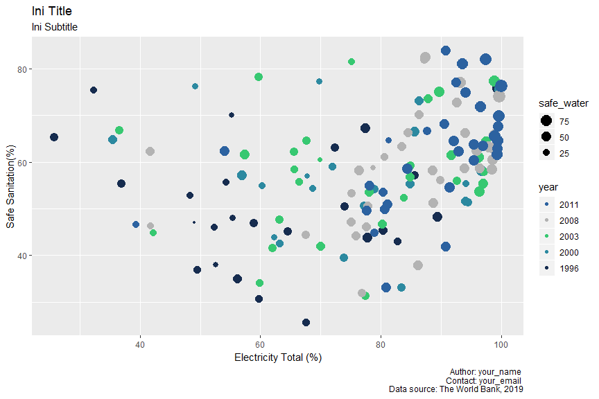

```r
plot_household <-
  plot_household +
  labs(
    title = "Ini Title",
    subtitle = "Ini Subtitle",
    caption = "Author: your_name \n Contact: your_email \n Data source: The World Bank, 2019",
    x = "Electricity Total (%)",
    y = "Safe Sanitation(%)",
    colour = "year",
    size = "safe_water"
  )
plot_household
```

Grafik tersebut sekarang sudah nampak lebih baik bukan? Namun Anda masih dapat melakukan kostumisasi tampilan lebih jauh dengan cara menggunakan *preset theme* (fungsi `theme_*()`) dan/atau bahkan berkreasi dengan menggunakan fungsi `theme()`. Pada *chunk* berikut kita akan memanfaatkan *preset theme* bernama *theme_minimal* dan menambahkan sedikit kostumisasi melalui fungsi `theme()`. Ubahlah posisi legenda menjadi ke bawah dengan mengganti nilai dari argumen `legend.position`!

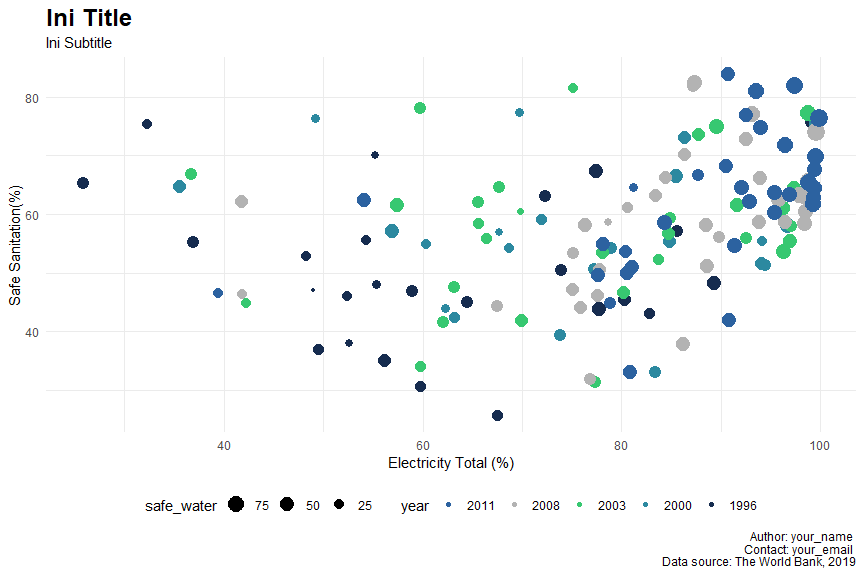

```r
plot_household <-
  plot_household +
  theme_minimal() +
  theme(
    text = element_text(family = "Lato"),
    plot.title = element_text(face = "bold", size = 18),
    legend.position = "bottom"
  )
plot_household
```

Selamat Anda telah sukses melakukan kostumisasi tampilan grafik! Sekarang Anda dapat menyimpan grafik tersebut dengan menggunakan fungsi `ggsave()` seperti contoh berikut:

```r
ggsave("household_access.png", plot_household, width = 20, height = 10, units = "cm")
```

Anda dapat menyimpan grafik dalam format png, pdf, svg, wmf. Selain itu Anda juga dapat mengatur ukuran serta resolusi dari grafik yang akan disimpan.

Selanjutnya pada *chunk* berikut akan ditunjukan salah satucara untuk menambahkan logo Anda atau logo perusahaan ke dalam grafik plot_household.

[figure not shown]

```r
logo <- image_read("../data-raw/sensolutionid.png") # berkas logo dengan format png atau jpg
plot_household
grid::grid.raster(logo, x = 0.0, y = 0.0, just = c('left', 'bottom'), height = unit(0.5, 'inches'))
```

Tuliskan kembali baris kode pada *chunk* di atas namun gantilah alamat berkas logo menjadi “../data-raw/telkom-university.png”!

Selain dengan menggunakan *preset theme* dari ggplot2 atau meracik tema sendiri, Anda juga dapat menggunakan paket-paket R yang menyediakan tema untuk ggplo2. Diantaranya adalah paket hrbrthemes ggpubr dan paket ggthemr. Pada modul selanjutnya Anda akan belajar menggunakan salahsatu tema dari paket tersebut. Namun sebelumnya, dapatkah Anda menambahkan baris kode `facet_wrap(~year)` pada plot_household? Apakah yang akan terjadi pada grafik tersebut?

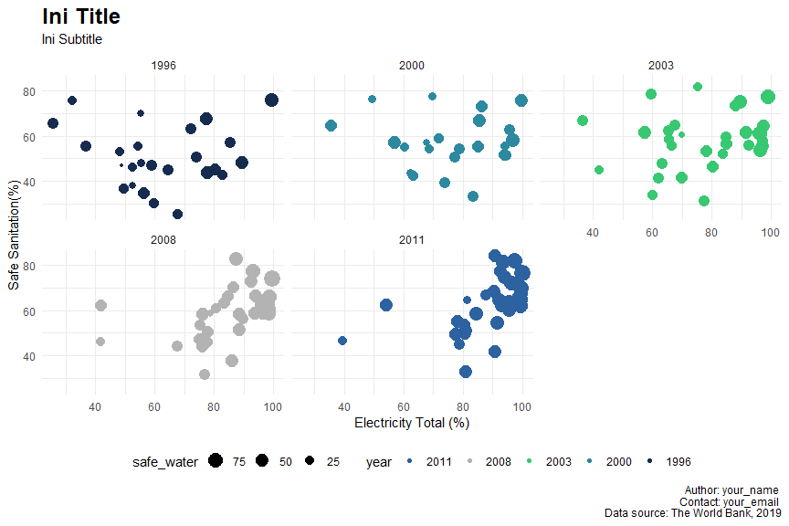

```r
plot_household +
  facet_wrap(~year)
```

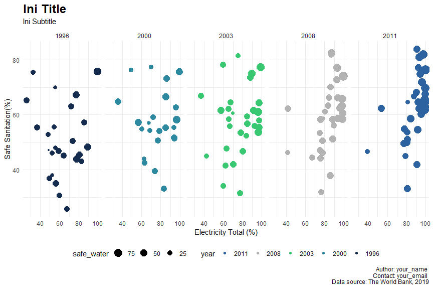

```r
plot_household +
  facet_grid(~year)
```